# **Project Foundations for Data Science: FoodHub Data Analysis**

**Marks: 40**

### Context

The number of restaurants in New York is increasing day by day. Lots of students and busy professionals rely on those restaurants due to their hectic lifestyles. Online food delivery service is a great option for them. It provides them with good food from their favorite restaurants. A food aggregator company FoodHub offers access to multiple restaurants through a single smartphone app.

The app allows the restaurants to receive a direct online order from a customer. The app assigns a delivery person from the company to pick up the order after it is confirmed by the restaurant. The delivery person then uses the map to reach the restaurant and waits for the food package. Once the food package is handed over to the delivery person, he/she confirms the pick-up in the app and travels to the customer's location to deliver the food. The delivery person confirms the drop-off in the app after delivering the food package to the customer. The customer can rate the order in the app. The food aggregator earns money by collecting a fixed margin of the delivery order from the restaurants.

### Objective

The food aggregator company has stored the data of the different orders made by the registered customers in their online portal. They want to analyze the data to get a fair idea about the demand of different restaurants which will help them in enhancing their customer experience. Suppose you are hired as a Data Scientist in this company and the Data Science team has shared some of the key questions that need to be answered. Perform the data analysis to find answers to these questions that will help the company to improve the business.

### Data Description

The data contains the different data related to a food order. The detailed data dictionary is given below.

### Data Dictionary

- order_id: Unique ID of the order
- customer_id: ID of the customer who ordered the food
- restaurant_name: Name of the restaurant
- cuisine_type: Cuisine ordered by the customer
- cost: Cost of the order
- day_of_the_week: Indicates whether the order is placed on a weekday or weekend (The weekday is from Monday to Friday and the weekend is Saturday and Sunday)
- rating: Rating given by the customer out of 5
- food_preparation_time: Time (in minutes) taken by the restaurant to prepare the food. This is calculated by taking the difference between the timestamps of the restaurant's order confirmation and the delivery person's pick-up confirmation.
- delivery_time: Time (in minutes) taken by the delivery person to deliver the food package. This is calculated by taking the difference between the timestamps of the delivery person's pick-up confirmation and drop-off information

### Let us start by importing the required libraries

```python
# import libraries for data manipulation
import numpy as np
import pandas as pd

# import libraries for data visualization
import matplotlib.pyplot as plt
import seaborn as sns
```

### Understanding the structure of the data

```python
from google.colab import drive
drive.mount('/content/drive')
```

```python
# read the data
df = pd.read_csv('/content/drive/MyDrive/PythonforDataScienceGL/foodhub_order.csv')
# returns the first 5 rows
df.head()
```

|  | order_id | customer_id | restaurant_name | cuisine_type | cost_of_the_order | day_of_the_week | rating | food_preparation_time | delivery_time |
| --- | --- | --- | --- | --- | --- | --- | --- | --- | --- |
| 0 | 1477147 | 337525 | Hangawi | Korean | 30.75 | Weekend | Not given | 25 | 20 |
| 1 | 1477685 | 358141 | Blue Ribbon Sushi Izakaya | Japanese | 12.08 | Weekend | Not given | 25 | 23 |
| 2 | 1477070 | 66393 | Cafe Habana | Mexican | 12.23 | Weekday | 5 | 23 | 28 |
| 3 | 1477334 | 106968 | Blue Ribbon Fried Chicken | American | 29.20 | Weekend | 3 | 25 | 15 |
| 4 | 1478249 | 76942 | Dirty Bird to Go | American | 11.59 | Weekday | 4 | 25 | 24 |

```python
df.info()
```

```
<class 'pandas.core.frame.DataFrame'>
RangeIndex: 1898 entries, 0 to 1897
Data columns (total 9 columns):
 #   Column                 Non-Null Count  Dtype
---  ------                 --------------  -----
 0   order_id               1898 non-null   int64
 1   customer_id            1898 non-null   int64
 2   restaurant_name        1898 non-null   object
 3   cuisine_type           1898 non-null   object
 4   cost_of_the_order      1898 non-null   float64
 5   day_of_the_week        1898 non-null   object
 6   rating                 1898 non-null   object
 7   food_preparation_time  1898 non-null   int64
 8   delivery_time          1898 non-null   int64
dtypes: float64(1), int64(4), object(4)
memory usage: 133.6+ KB
```

```python
df.describe().T
```

|  | count | mean | std | min | 25% | 50% | 75% | max |
| --- | --- | --- | --- | --- | --- | --- | --- | --- |
| order_id | 1898.0 | 1.477496e+06 | 548.049724 | 1476547.00 | 1477021.25 | 1477495.50 | 1.477970e+06 | 1478444.00 |
| customer_id | 1898.0 | 1.711685e+05 | 113698.139743 | 1311.00 | 77787.75 | 128600.00 | 2.705250e+05 | 405334.00 |
| cost_of_the_order | 1898.0 | 1.649885e+01 | 7.483812 | 4.47 | 12.08 | 14.14 | 2.229750e+01 | 35.41 |
| food_preparation_time | 1898.0 | 2.737197e+01 | 4.632481 | 20.00 | 23.00 | 27.00 | 3.100000e+01 | 35.00 |
| delivery_time | 1898.0 | 2.416175e+01 | 4.972637 | 15.00 | 20.00 | 25.00 | 2.800000e+01 | 33.00 |

#### **Observations:**

The DataFrame has 9 columns as mentioned in the Data Dictionary. Data in each row corresponds to the order placed by a customer.

### **Question 1:** How many rows and columns are present in the data?

```python
rows, columns = df.shape
print(f"The dataset contains {rows} rows and {columns} columns.")
```

```
The dataset contains 1898 rows and 9 columns.
```

```python
df.info()
```

```
<class 'pandas.core.frame.DataFrame'>
RangeIndex: 1898 entries, 0 to 1897
Data columns (total 9 columns):
 #   Column                 Non-Null Count  Dtype
---  ------                 --------------  -----
 0   order_id               1898 non-null   int64
 1   customer_id            1898 non-null   int64
 2   restaurant_name        1898 non-null   object
 3   cuisine_type           1898 non-null   object
 4   cost_of_the_order      1898 non-null   float64
 5   day_of_the_week        1898 non-null   object
 6   rating                 1898 non-null   object
 7   food_preparation_time  1898 non-null   int64
 8   delivery_time          1898 non-null   int64
dtypes: float64(1), int64(4), object(4)
memory usage: 133.6+ KB
```

As per the information given on data above using df.info(), there are a total of 1898 rows, and a total of 9 columns.

### **Question 2:** What are the datatypes of the different columns in the dataset? (The info() function can be used)

```python
df.info()
```

```
<class 'pandas.core.frame.DataFrame'>
RangeIndex: 1898 entries, 0 to 1897
Data columns (total 9 columns):
 #   Column                 Non-Null Count  Dtype
---  ------                 --------------  -----
 0   order_id               1898 non-null   int64
 1   customer_id            1898 non-null   int64
 2   restaurant_name        1898 non-null   object
 3   cuisine_type           1898 non-null   object
 4   cost_of_the_order      1898 non-null   float64
 5   day_of_the_week        1898 non-null   object
 6   rating                 1898 non-null   object
 7   food_preparation_time  1898 non-null   int64
 8   delivery_time          1898 non-null   int64
dtypes: float64(1), int64(4), object(4)
memory usage: 133.6+ KB
```

As seen in the above section, the data type for each column has been given below:

order_id: int64

customer_id: int64

restaurant_name: object

cuisine_type: object

cost_of_the_order: float64

day_of_the_week: object

rating: object

food_preparation_time: int64

delivery_time: int64

### **Question 3:** Are there any missing values in the data? If yes, treat them using an appropriate method

```python
missing_values = df.isnull().sum()
print("Missing values before treatment:\n", missing_values)
```

```
Missing values before treatment:
 order_id                 0
customer_id              0
restaurant_name          0
cuisine_type             0
cost_of_the_order        0
day_of_the_week          0
rating                   0
food_preparation_time    0
delivery_time            0
dtype: int64
```

This means that there are 0 null values for each of the given columns. But for further check, I have checked null values for each column in the codes given below.

```python
has_nullorder = df['order_id'].isnull().any()
if has_nullorder == True:
    print("There are missing values in the order_id column of the data.")
else:
    print("There are no missing values in the order_id column of the data.")
```

```
There are no missing values in the order_id column of the data.
```

```python
has_nullcus = df['customer_id'].isnull().any()
if has_nullcus == True:
    print("There are missing values in the customer_id column of the data.")
else:
    print("There are no missing values in the customer_id column of the data.")
```

```
There are no missing values in the customer_id column of the data.
```

```python
has_nullresname = df['restaurant_name'].isnull().any()
if has_nullresname == True:
    print("There are missing values in the restaurant_name column of the data.")
else:
    print("There are no missing values in the restaurant_name column of the data.")
```

```
There are no missing values in the restaurant_name column of the data.
```

```python
has_nullcui = df['cuisine_type'].isnull().any()
if has_nullcui == True:
    print("There are missing values in the cuisine_type column of the data.")
else:
    print("There are no missing values in the cuisine_type column of the data.")
```

```
There are no missing values in the cuisine_type column of the data.
```

```python
has_nullcost = df['cost_of_the_order'].isnull().any()
if has_nullcost == True:
    print("There are missing values in the cost column of the data.")
else:
    print("There are no missing values in the cost column of the data.")
```

```
There are no missing values in the cost column of the data.
```

```python
has_nullday = df['day_of_the_week'].isnull().any()
if has_nullday == True:
    print("There are missing values in the day_of_the_week column of the data.")
else:
    print("There are no missing values in the day_of_the_week column of the data.")
```

```
There are no missing values in the day_of_the_week column of the data.
```

```python
has_nullrating = df['rating'].isnull().any()
if has_nullrating == True:
    print("There are missing values in the rating column of the data.")
else:
    print("There are no missing values in the rating column of the data.")
```

```
There are no missing values in the rating column of the data.
```

```python
has_nullfpt = df['food_preparation_time'].isnull().any()
if has_nullfpt == True:
    print("There are missing values in the food_preparation_time column of the data.")
else:
    print("There are no missing values in the food_preparation_time column of the data.")
```

```
There are no missing values in the food_preparation_time column of the data.
```

```python
has_nulldt = df['delivery_time'].isnull().any()
if has_nulldt == True:
    print("There are missing values in the delivery_time column of the data.")
else:
    print("There are no missing values in the delivery_time column of the data.")
```

```
There are no missing values in the delivery_time column of the data.
```

No, there are no missing values in the data because all the columns have the same number of rows with a non-null value that equals the total number of rows in the data.

But for further complete check, I checked to see if each column has any null value and as seen with the codes above, there are no null values in any given columns. Therefore, I did not have to treat it with the procedures of missing values.

### **Question 4:** Check the statistical summary of the data. What is the minimum, average, and maximum time it takes for food to be prepared once an order is placed?

```python
df.describe().T
```

|  | count | mean | std | min | 25% | 50% | 75% | max |
| --- | --- | --- | --- | --- | --- | --- | --- | --- |
| order_id | 1898.0 | 1.477496e+06 | 548.049724 | 1476547.00 | 1477021.25 | 1477495.50 | 1.477970e+06 | 1478444.00 |
| customer_id | 1898.0 | 1.711685e+05 | 113698.139743 | 1311.00 | 77787.75 | 128600.00 | 2.705250e+05 | 405334.00 |
| cost_of_the_order | 1898.0 | 1.649885e+01 | 7.483812 | 4.47 | 12.08 | 14.14 | 2.229750e+01 | 35.41 |
| food_preparation_time | 1898.0 | 2.737197e+01 | 4.632481 | 20.00 | 23.00 | 27.00 | 3.100000e+01 | 35.00 |
| delivery_time | 1898.0 | 2.416175e+01 | 4.972637 | 15.00 | 20.00 | 25.00 | 2.800000e+01 | 33.00 |

The minimum time taken for food preparation after an order has been placed is 20, average time is 27.372, maximum time is 35.

### **Question 5:** How many orders are not rated?

```python
# Count orders that are not rated
unrated_orders = (df['rating'] == 'Not given').sum()
print(f"Number of unrated orders: {unrated_orders}")
```

```
Number of unrated orders: 736
```

Therefore, there are 736 non-rated orders in the given data.

### Exploratory Data Analysis (EDA)

### **Question 6:** Explore all the variables and provide observations on their distributions. (Generally, histograms, boxplots, countplots, etc. are used for univariate exploration)

```python
import matplotlib.pyplot as plt
import seaborn as sns
```

#### Customer ID

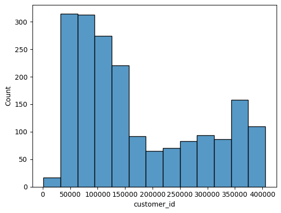

```python
sns.histplot(data = df, x = 'customer_id')
plt.show()
```

#### Restaurants

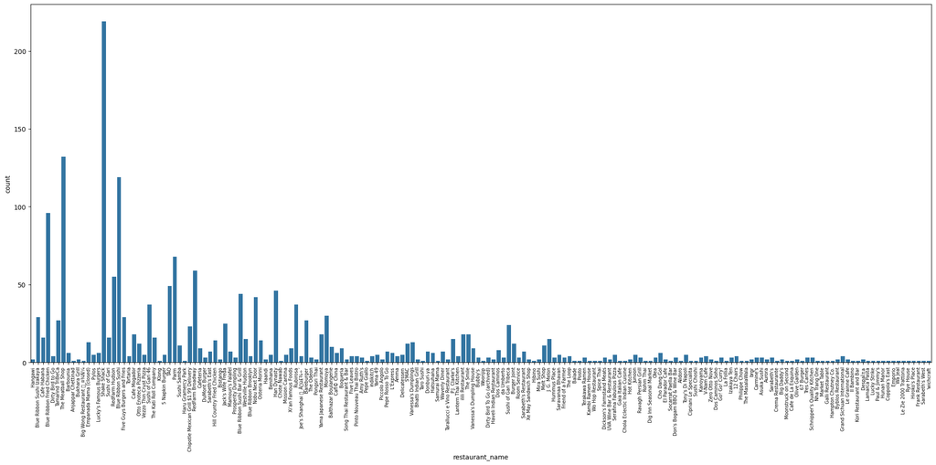

```python
fig, ax = plt.subplots(figsize=(25, 10))
sns.countplot(data = df, x = 'restaurant_name')
plt.xticks(rotation=90)
plt.xticks(fontsize=7)
plt.show()
```

```python
total_restaurants = df['restaurant_name'].nunique()
print(f"Total number of restaurants: {total_restaurants}")
```

```
Total number of restaurants: 178
```

The above diagram gives the total number of orders placed at each restaurant. There are a total of 178 restaurants and it became difficult to fit it in a size that can be easily understood by looking, therefore I pulled out the top 10 and the bottom 10 restaurants where orders are placed based on the given dataset.

```python
top_10_restaurants = df['restaurant_name'].value_counts().head(10)
print(top_10_restaurants)
```

```
restaurant_name
Shake Shack                      219
The Meatball Shop                132
Blue Ribbon Sushi                119
Blue Ribbon Fried Chicken         96
Parm                              68
RedFarm Broadway                  59
RedFarm Hudson                    55
TAO                               49
Han Dynasty                       46
Blue Ribbon Sushi Bar & Grill     44
Name: count, dtype: int64
```

```python
bot_10_restaurants = df['restaurant_name'].value_counts().tail(10)
print(bot_10_restaurants)
```

```
restaurant_name
Rohm Thai                  1
Dig Inn Seasonal Market    1
Socarrat Paella Bar        1
Alidoro                    1
Cipriani Le Specialita     1
Sushi Choshi               1
Dos Caminos Soho           1
La Follia                  1
Philippe Chow              1
'wichcraft                 1
Name: count, dtype: int64
```